# Course Project 2: Storm Analysis

Alberto Rossi

02/06/2020

# Synopsis

This document is the result of a study on climate data in the USA. The objective is to understand which types of weather events have the greatest impact on people’s health, as well as which events cause the greatest financial damage.

# Data Loading and Transformations

The data was loaded from the download of the raw source made available by NOAA.

From there, the usual validations of the file were made, as well as some transformations in the format of some columns, aiming to facilitate the calculations and the subsequent groupings.

Reading and confirming data:

```r
    zipfile <- "repdata_data_StormData.csv.bz2"
    filename <- "repdata_data_StormData.csv.bz2"
    fileURL <- "https://d396qusza40orc.cloudfront.net/repdata%2Fdata%2FStormData.csv.bz2"

    #Zip already exists?
    if (!file.exists(zipfile)){
        download.file(fileURL, zipfile)
    }

    #Store data for reading - direct from bz2
    arquivoOrigin <- read.table(filename,
                          sep = ",",
                          header = TRUE,
                          dec = ".",
                          na.strings = "")

    #Re-storing dates values for better work
    arquivo <- arquivoOrigin
```

Converting some of data. Here it was necessary to transform some of the data according to the explanations provided by the data provider.

```r
    #Convert date to easy work
    library(lubridate)
    arquivo$BGN_DATE <- mdy_hms(arquivo[,2])

    #Convert lower case exponent letter codes
    arquivo$PROPDMGEXP <- toupper(as.character(arquivo$PROPDMGEXP))
    arquivo$CROPDMGEXP <- toupper(as.character(arquivo$CROPDMGEXP))

    # Convert codes to "NA", to not interfe with analysis
    arquivo$PROPDMGEXP[(arquivo$PROPDMGEXP == "-")] <- "NA"
    arquivo$PROPDMGEXP[(arquivo$PROPDMGEXP == "+")] <- "NA"
    arquivo$PROPDMGEXP[(arquivo$PROPDMGEXP == "?")] <- "NA"
    arquivo$CROPDMGEXP[(arquivo$CROPDMGEXP == "-")] <- "NA"
    arquivo$CROPDMGEXP[(arquivo$CROPDMGEXP == "+")] <- "NA"
    arquivo$CROPDMGEXP[(arquivo$CROPDMGEXP == "?")] <- "NA"

    #Convert missing values "" to 0, to not interfe with analysis
    arquivo$FATALITIES[(arquivo$FATALITIES == "")] <- 0
    arquivo$INJURIES[(arquivo$INJURIES == "")] <- 0
    arquivo$PROPDMG[(arquivo$PROPDMG == "")] <- 0
    arquivo$CROPDMG[(arquivo$CROPDMG == "")] <- 0
    arquivo$PROPDMGEXP[(arquivo$PROPDMGEXP == "")] <- 0
    arquivo$CROPDMGEXP[(arquivo$CROPDMGEXP == "")] <- 0

    #Transform character codes to numeric, to
    #calculate exponents
    arquivo$PROPDMGEXP[(arquivo$PROPDMGEXP == "H")] <- 2
    arquivo$PROPDMGEXP[(arquivo$PROPDMGEXP == "K")] <- 3
    arquivo$PROPDMGEXP[(arquivo$PROPDMGEXP == "M")] <- 6
    arquivo$PROPDMGEXP[(arquivo$PROPDMGEXP == "B")] <- 9
    arquivo$CROPDMGEXP[(arquivo$CROPDMGEXP == "H")] <- 2
    arquivo$CROPDMGEXP[(arquivo$CROPDMGEXP == "K")] <- 3
    arquivo$CROPDMGEXP[(arquivo$CROPDMGEXP == "M")] <- 6
    arquivo$CROPDMGEXP[(arquivo$CROPDMGEXP == "B")] <- 9

    #Transform exponents as integers for easy calculation
    arquivo$PROPDMGEXP <- as.integer(arquivo$PROPDMGEXP)
    arquivo$CROPDMGEXP <- as.integer(arquivo$CROPDMGEXP)
```

# Results

Once the appropriate procedures have been applied, the results are simple to obtain. Basically the data goes through some groupings and orderings, so that two main questions can be answered.

## 1.Across the United States, which types of events (as indicated in the EVTYPE) are most harmful with respect to population health?

Fatality and injury data were grouped by event, and ordered in descending order so that the main causative events were easily identifiable.

```r
    # Check for missing values from EVTYPE
    any(is.na(arquivo$EVTYPE))
```

```
## [1] FALSE
```

```r
    # No NAs.

    # Check what is the most harmful event,
    # by Fatalities and Injuries

    #Grouping the sum of Fatalities by Event and
    #ordering in descending way to check most harmful

    library(dplyr)
    #Fatality
    evfat <- aggregate(FATALITIES ~ EVTYPE,
                       arquivo,
                       sum)

    evfat <- evfat %>% arrange(desc(FATALITIES))
    print(paste("Most frequent fatality: ", evfat[1,]))
```

```
## [1] "Most frequent fatality:  TORNADO" "Most frequent fatality:  5633"
```

```r
    #Injury
    evinj <- aggregate(INJURIES ~ EVTYPE,
                       arquivo,
                       sum)

    evinj<- evinj %>% arrange(desc(INJURIES))
    print(paste("Most frequent injury: ", evinj[1,]))
```

```
## [1] "Most frequent injury:  TORNADO" "Most frequent injury:  91346"
```

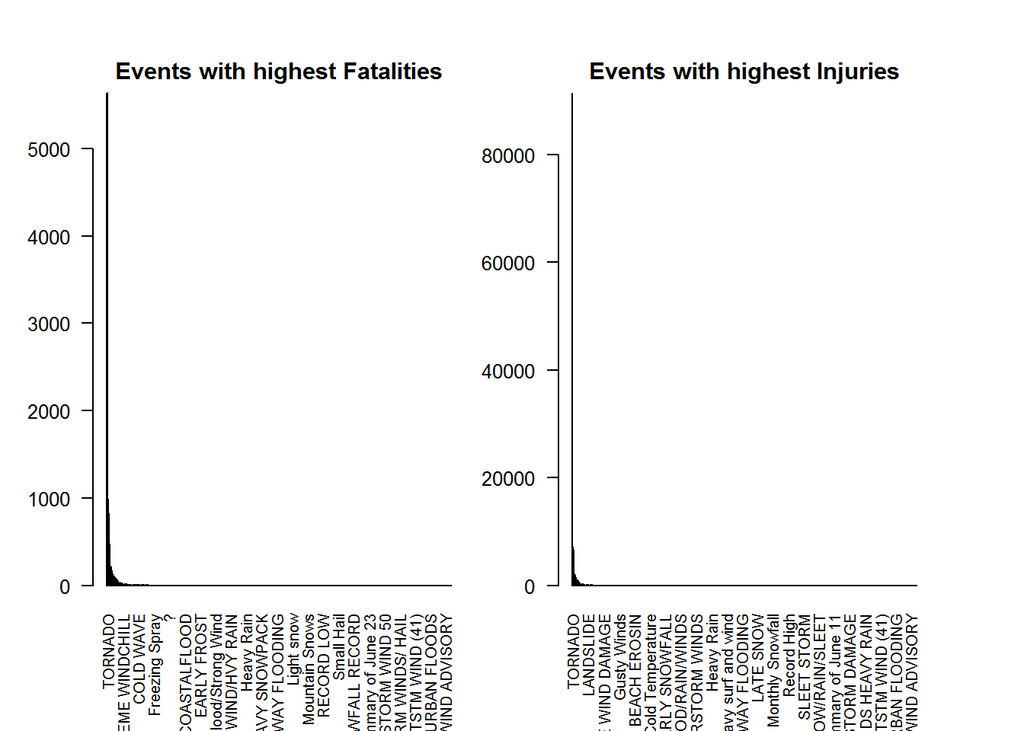

```r
    par(mfrow=c(1,2), mar=c(2,2,2,2), oma=c(4,2,2,2), cex=0.8)
    barplot(evfat$FATALITIES, names.arg=evfat$EVTYPE, las=2,
            cex.names=0.8, xlab="", ylab="Fatalities", col="blue",
            main="Events with highest Fatalities")
    barplot(evinj$INJURIES, names.arg=evinj$EVTYPE, las=2,
            cex.names=0.8, xlab="", ylab="Injuries", col="blue",
            main="Events with highest Injuries")
```

## 2.Across the United States, which types of events have the greatest economic consequences?

Data on property damage and damage to crops were grouped by event, and ordered in descending order so that the main causative events were easily identifiable.

It is important that a conversion factor was applied here, according to details of the data supplier.

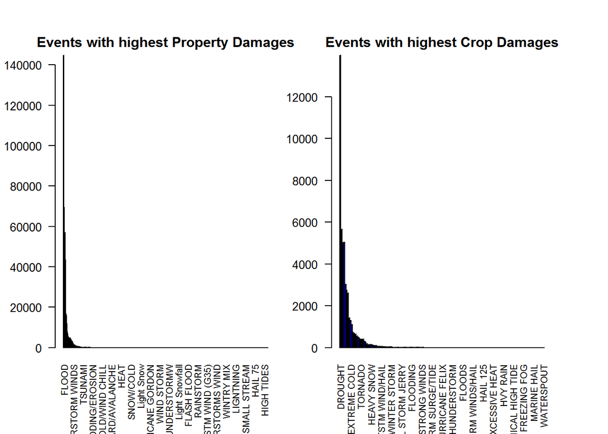

```r
    # Calculate actual property and crop damage value
    arquivo$PROPDMGTOTAL <- arquivo$PROPDMG * 10^arquivo$PROPDMGEXP
    arquivo$CROPDMGTOTAL <- arquivo$CROPDMG * 10^arquivo$CROPDMGEXP

    #Grouping the sum of Property Damage by Event and
    #ordering in descending way to check who has greatest
    #economic consequences

    #Property grouping
    evpd <- aggregate(PROPDMGTOTAL ~ EVTYPE,
                       arquivo,
                       sum)
    evpd <- evpd %>% arrange(desc(PROPDMGTOTAL))
    par(mfrow=c(1,2), mar=c(2,2,2,2), oma=c(4,2,2,2), cex=0.8)
    barplot(evpd$PROPDMGTOTAL/10^6, names.arg=evpd$EVTYPE, las=2,
            cex.names=0.8, xlab="", ylab="Property Damage",
            col="red", main="Events with highest Property Damages")

    #Crop grouping
    evcd <- aggregate(CROPDMGTOTAL ~ EVTYPE,
                      arquivo,
                      sum)
    evcd <- evcd %>% arrange(desc(CROPDMGTOTAL))
    barplot(evcd$CROPDMGTOTAL/10^6, names.arg=evcd$EVTYPE, las=2,
            cex.names=0.8, xlab="", ylab="Crop Damage", col="blue",
            main="Events with highest Crop Damages")
```